# Department of Agriculture

## 11.2 The agencies in brief

**Bureau of Fisheries and Aquatic Resources (BFAR)** is by far the largest attached agency — ₱6.1B in 2018 nearly doubling to ₱11.8B in 2026 — covering fisheries production, monitoring/control/surveillance, post-harvest infrastructure, and aquaculture. It is also the most consistently augmented: cumulatively Congress added ₱4.2B over its proposals, most strikingly +₱1.9B in 2024. The World Bank–funded **FishCORE** (Philippine Fisheries and Coastal Resiliency Project) has grown into a ₱2B line, the agency’s second-largest, signalling a shift toward externally-financed coastal resilience.

**Agricultural Credit Policy Council (ACPC)** tripled from ₱1.1B to ₱3.1B, but is effectively a one-program agency: the **Agro-Industry Modernization Credit and Financing Program (AMCFP)** is about 97% of its budget, with all other lines together under ₱0.1B. Congress has been a slight net *trimmer* here over the period (−₱0.1B cumulative), including a notable ₱1.0B cut to the 2019 NEP. A single-program agency wrapped in management overhead invites the structural question of whether AMCFP needs its own agency at all.

**Philippine Carabao Center (PCC)** more than doubled into 2026 — from ₱0.5B (2018) to ₱2.1B — almost entirely because of a **+₱1.1B Congressional add for a new school milk-feeding program** (a component of DepEd’s School-Based Feeding Program) that had essentially no NEP line. That single insertion is now PCC’s largest item, eclipsing its core dairy-buffalo breeding and herd build-up work. It assigns a school-feeding delivery mandate to a small research-and-breeding agency.

**National Fisheries Research and Development Institute (NFRDI)** is the newest meaningful unit, with no DA line before 2020, growing to ₱0.74B by 2026. Its mandate is fisheries research distinct from BFAR’s operations. Research is about 63% of its budget; general management is a heavy ~31%, characteristic of a young, still-scaling institution. Congress has been almost entirely hands-off, enacting the NEP as proposed in nearly every year.

**Philippine Center for Postharvest Development and Mechanization (PHilMech)** focuses on postharvest technology, mechanization research, and farmer extension. It is remarkably static — ₱0.3–0.5B across nine years — and is the one agency whose NEP has been enacted as-is in *every* year, without a single peso of Congressional adjustment. Operationally it is essentially two lines, extension (ESETS) and R&D, mirroring its mandate.

**Fertilizer and Pesticide Authority (FPA)** regulates fertilizer and pesticide registration, licensing, and quality control. It had no DA line until 2019 (established by a +₱0.2B Congressional add when the NEP was zero) and has grown slowly to ₱0.42B, with the 2026 step-up its largest single-year increase. Two regulatory lines carry most of the budget.

### The master table: every attached-agency P/A/P, 2025–2027

Every attached-agency P/A/P, with **NEP and GAA for FY 2025, 2026, and the FY 2027 proposal**, and the proposed change from the 2026 enacted level. Search by agency short-name or program, and sort by the change column to see which lines the FY 2027 NEP grows or cuts. **These agencies have no P/A/P-level execution data**, so — unlike the OSEC master table — there are no utilization columns; the appropriations themselves are the lever advocates can act on before enactment.

```r
att_full <- df_long %>% filter(!is_osec, metric %in% c("NEP","GAA")) %>%
  group_by(agency, pap, year, metric) %>% summarise(v = sum(amount, na.rm = TRUE), .groups = "drop") %>%
  pivot_wider(names_from = c(metric, year), values_from = v)
gc <- function(nm) if (nm %in% names(att_full)) att_full[[nm]] else NA_real_
att_full <- att_full %>% transmute(Agency = recode(agency, !!!short_map), `P/A/P` = str_trunc(pap, 62),
            `NEP 2025 (B)` = gc("NEP_2025")/1e9, `GAA 2025 (B)` = gc("GAA_2025")/1e9,
            `NEP 2026 (B)` = gc("NEP_2026")/1e9, `GAA 2026 (B)` = gc("GAA_2026")/1e9,
            `NEP 2027 (B)` = gc("NEP_2027")/1e9,
            `Proposed chg 26→27 (B)` = (gc("NEP_2027") - gc("GAA_2026"))/1e9) %>%
  arrange(Agency, desc(`NEP 2027 (B)`))
dt_table(att_full, page = 15,
         money_cols = c("NEP 2025 (B)","GAA 2025 (B)","NEP 2026 (B)","GAA 2026 (B)","NEP 2027 (B)","Proposed chg 26→27 (B)"),
         money_digits = 3)
```

| Agency | P/A/P | NEP 2025 (B) | GAA 2025 (B) | NEP 2026 (B) | GAA 2026 (B) | NEP 2027 (B) | Proposed chg 26→27 (B) |
| --- | --- | --- | --- | --- | --- | --- | --- |
| ACPC | Agro-Industry Modernization Credit and Financing Program (A... | 2.77182 | 2.77182 | 2.774363 | 3.024363 | 2.775135 | -0.249228 |
| ACPC | Policy Formulation, Research and Advocacy, Monitoring and E... | 0.057918 | 0.057918 | 0.057195 | 0.057195 | 0.060131 | 0.002936 |
| ACPC | General Management and Supervision | 0.031236 | 0.031236 | 0.028864 | 0.028864 | 0.02392 | -0.004944 |
| ACPC | Administration of Personnel Benefits | 0 | 0 | 0.003699 | 0.003699 | 0.001935 | -0.001764 |
| ACPC | Agripreneurship Program | 0 | 0 | 0 | 0 | 0 | 0 |
| ACPC | Agro-Industry Modernization Credit and Financing Program (A... | 0 | 0 | 0 | 0 | 0 | 0 |
| BFAR | Fisheries Production and Distribution | 1.68514 | 1.68514 | 2.048424 | 2.054234 | 2.011076 | -0.043158 |
| BFAR | Operation and Management of Production Facilities | 1.366602 | 1.420294 | 1.274751 | 1.277336 | 1.893995 | 0.616659 |
| BFAR | Philippine Fisheries and Coastal Resiliency Project (FishCO... | 2.22718 | 2.22718 | 2.035503 | 2.035503 | 1.798079 | -0.237424 |
| BFAR | Monitoring, Control and Surveillance | 0.611307 | 0.626777 | 1.074593 | 1.408593 | 1.673757 | 0.265164 |

[output cut: 95 more lines]

# Section 3 — Department-Wide Perspective

# 12 The whole Department of Agriculture

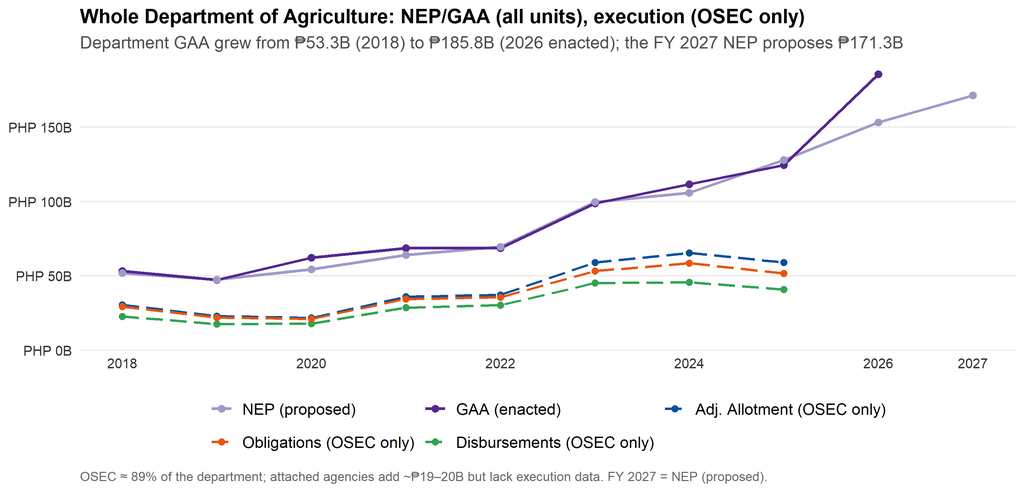

```r
dept_totals <- df_long %>% group_by(year, metric) %>%
  summarise(total = if (all(is.na(amount))) NA_real_ else sum(amount, na.rm = TRUE), .groups = "drop") %>%
  filter(!is.na(total))
evo2 <- dept_totals %>% filter(metric %in% c("NEP","GAA")) %>%
  mutate(metric = factor(metric, levels = c("NEP","GAA"), labels = c("NEP (proposed)","GAA (enacted)")))
osec_exec <- df_long %>% filter(is_osec, metric %in% c("AdjAllot","Obligations","Disbursements")) %>%
  group_by(year, metric) %>%
  summarise(total = if (all(is.na(amount))) NA_real_ else sum(amount, na.rm = TRUE), .groups = "drop") %>%
  filter(!is.na(total)) %>%
  mutate(metric = factor(metric, levels = c("AdjAllot","Obligations","Disbursements"),
    labels = c("Adj. Allotment (OSEC only)","Obligations (OSEC only)","Disbursements (OSEC only)")))
ev_pal <- c("NEP (proposed)" = "#9E9AC8","GAA (enacted)" = "#54278F",
  "Adj. Allotment (OSEC only)" = "#08519C","Obligations (OSEC only)" = "#E6550D","Disbursements (OSEC only)" = "#31A354")
ggplot() +
  geom_line(data = evo2, aes(year, total, color = metric, group = metric), linewidth = 1.0) +
  geom_point(data = evo2, aes(year, total, color = metric), size = 2) +
  geom_line(data = osec_exec, aes(year, total, color = metric, group = metric), linewidth = 0.8, linetype = "longdash") +
  geom_point(data = osec_exec, aes(year, total, color = metric), size = 1.8) +
  scale_color_manual(values = ev_pal, limits = names(ev_pal)) +
  scale_y_continuous(labels = php_b_axis, breaks = pretty_breaks(6), limits = c(0, NA), expand = expansion(mult = c(0, .05))) +
  scale_x_continuous(breaks = c(seq(2018, 2026, 2), 2027)) +
  labs(title = "Whole Department of Agriculture: NEP/GAA (all units), execution (OSEC only)",
       subtitle = "Department GAA grew from ₱53.3B (2018) to ₱185.8B (2026 enacted); the FY 2027 NEP proposes ₱171.3B",
       x = NULL, y = NULL,
       caption = "OSEC ≈ 89% of the department; attached agencies add ~₱19–20B but lack execution data. FY 2027 = NEP (proposed).") +
  theme_da() + guides(color = guide_legend(nrow = 2, byrow = TRUE))
```

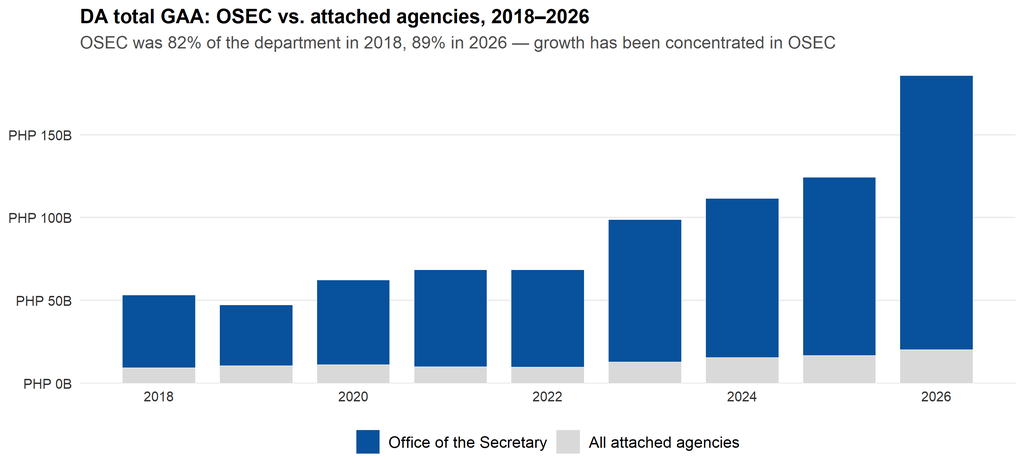

```r
share <- df_long %>% filter(metric == "GAA", year <= 2026, !is.na(amount)) %>%
  mutate(grp = ifelse(is_osec, "Office of the Secretary", "All attached agencies")) %>%
  group_by(year, grp) %>% summarise(amount = sum(amount, na.rm = TRUE), .groups = "drop") %>%
  mutate(grp = factor(grp, levels = c("Office of the Secretary","All attached agencies")))
ggplot(share, aes(year, amount, fill = grp)) +
  geom_col(width = 0.75, color = "white", linewidth = 0.2) +
  scale_fill_manual(values = c("Office of the Secretary" = "#08519C","All attached agencies" = "#D9D9D9")) +
  scale_y_continuous(labels = php_b_axis, breaks = pretty_breaks(6), limits = c(0, NA), expand = expansion(mult = c(0, .05))) +
  scale_x_continuous(breaks = seq(2018, 2026, 2)) +
  labs(title = "DA total GAA: OSEC vs. attached agencies, 2018–2026",
       subtitle = "OSEC was 82% of the department in 2018, 89% in 2026 — growth has been concentrated in OSEC",
       x = NULL, y = NULL) +
  theme_da() + guides(fill = guide_legend(nrow = 1))
```

The Executive has concentrated the department’s growth in the Office of the Secretary, whose share rose from 82% to 89%. The attached agencies — with the partial exception of BFAR and the Congressionally-boosted PCC — have grown only slowly.